# Final Project Report

Grant Ruedy & Andrew Sundberg

5/4/2019

### Background

Both of us are sports fans, and more specifically NBA fans. We thought it would be fun to base our project around a topic we were already familiar with to make the data exploration more meaningful and interesting. The NBA is the highest level of basketball in the world, so we figured there would be plenty of data available regarding player and team statistics. The data set we used contained measureable basketball statistics, like points, rebounds, blocks, steals, turnovers, etc. for NBA players from 1950 to 2017. This data set had over 25,000 observations, for 53 different variables.

### Questions Raised

There were many things we were curious about that could hopefully be answered from our data set. The first question we asked was what makes a winning team? Obviously there are many different parts to the game of basketball, but we wanted to know what parts were morst important for helping a team win. If a certain aspect of the game (such as assists or steals for example) is proven to be statisically beneficial in determining a team’s record, then players would want to make sure they focus their time practicing those important parts of the game. We wanted to compare these different basketball statistics between good and bad teams (based off their record), and see if there were any trends or patterns.

The next question we had was what position is most important? Basketball is made up of 5 different positions: center, power forward, point guard, small forward, and shooting guard. We were curious to see which positions were most beneficial in determining a team’s wins.

The final question we had from our data set was is it better to have younger or older players? Teams should want to make sure they are signing players who are at the age that is proven to be most productive for helping the team win. We wanted to look at the basketball stats among different aged players, and see if there were any trends or differences.

### Cleaning the Dataset

The data set we worked with was already pretty clean to start with. However, there were several columns with empty data as well as some columns that were repeated. To fix this, we simply subsetted the data set by taking away such columns. We then cleaned the data by subsetting it to where the year was equal to 2017. This would make it so we could analyze a lot deeper into one season, instead of having to deal with 60+ seasons. Once we subsetted by year, we had to remove obseravtions where the team was outdated. There were 8 teams that were no longer in the NBA in 2017, that must have been there years before. Also, we had to figure out how to combine the original data set with our data set of teams and wins. To do this, we used an inner join, by the team name. All of these steps are shown below.

```r
nba2017 <- filter(nba, Year >= 2017)
nba2017_recent <- filter(nba2017, !Tm %in% c('TOT', 'CHA', 'CHH', 'NJN', 'NOH', 'NOK','SEA','VAN'))
nba.clean <- inner_join(nba2017_recent, wins, by='Tm')
```

### Exploratory Analysis

```r
cor(nba.clean1$Wins, nba.clean)
```

[output not shown]

The only variable that had any strong correaltion with wins was points scored, which had a correlation of .62. This made a lot of sense, as scoring as many points as possible will improve your chances of outscoring your opponent. We also wanted to get a good understanding of how all the teams in 2017 performed. To do this, we made a simple scatterplot showing wins for each team. The line represents teams that made the playoffs. Teams only needed to win 46/82 or ~ 56% of their games to make the playoffs. This seemed kind of low and surprised us. The graph is shown below.

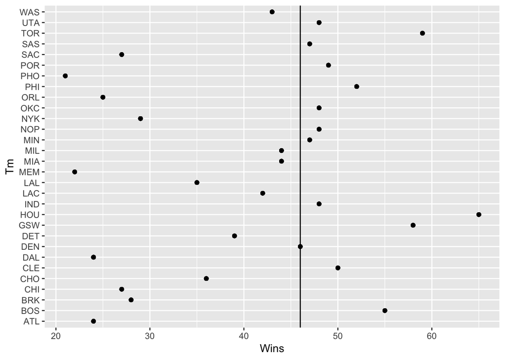

### Data Wrangling and Visualization

```r
nba.clean.best <- filter(nba.clean1, Tm =='GSW' | Tm =='HOU' | Tm == 'TOR' & GS > 25)
nba.clean.worst <- filter(nba.clean1, Tm =='PHO' | Tm =='MEM' | Tm == 'DAL' & GS > 25)
```

Next, we wanted to make team stats based on averaging the stats for each player on that team. To do this, we used dplyr to group by the team, then add a column based off the average for that statistic. We did this for the two data sets containing the worst and best teams. Below is an example of what we did, not incuding every variable we used to avoid redundancy. Here, TmAST corresponds to the average amount of assists performed by players on that particular team. The same goes for steals (STL).

```r
nba.clean.best1 <- nba.clean.best1 %>% group_by(Tm) %>% mutate(TmAST. = mean(AST.))
nba.clean.best1 <- nba.clean.best1 %>% group_by(Tm) %>% mutate(TmSTL. = mean(STL.))

nba.clean.worst1 <- nba.clean.worst1 %>% group_by(Tm) %>% mutate(TmAST. = mean(AST.))
nba.clean.worst1 <- nba.clean.worst1 %>% group_by(Tm) %>% mutate(TmSTL. = mean(STL.))
```

We then wanted to visualize team points among the best and worst teams. To do this, we graphed the points scored by each player, between the best 3 teams and worst 3 teams. Since points had the strongest correlation to wins, we figured this variable would provide the most interesting results. the colored lines represent the average points for that particular team. The visualizations of points per player is shown below, one graph for the best teams and one graph for the worst teams.

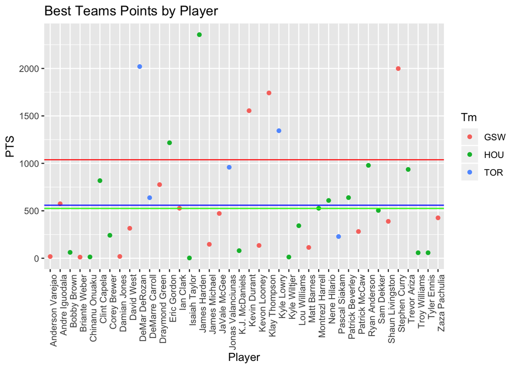

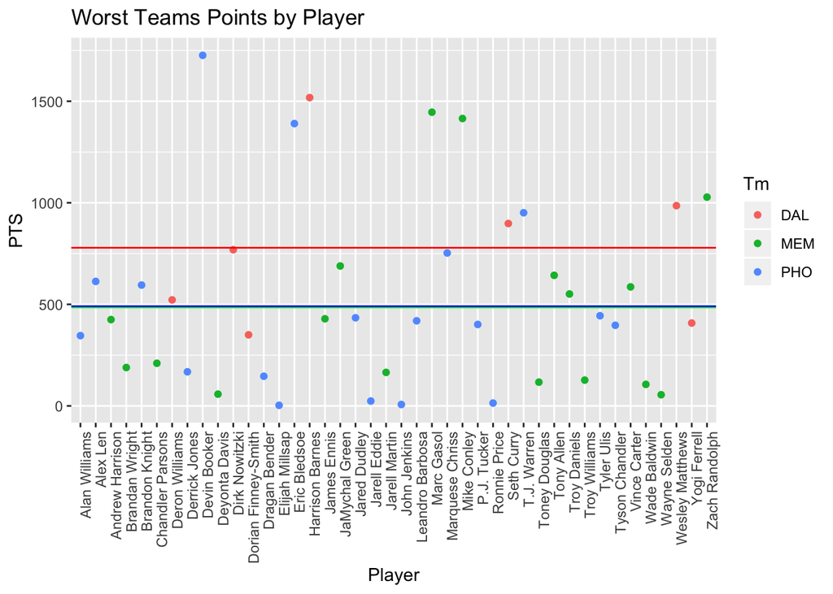

Next, we wanted to go beyond visualizations and correlations to see what makes good teams good. To do this, we fit a regression model including most of the basic ‘box-score’ type of varibles as well as some more complicated ones as our predictors, for predicting wins. This would allow us to see what varibles are significant in our model, and hence important for determining a teams wins and whether they are a good team or not. We used basic stepwise selection as well as some more complicated diagnostics to choose the best model. The results from the stepwise selection are shown below, as they are the same as our more complication methods.

```r
m1 <-glm(Wins~ eFG. + AST + TRB + STL + BLK + FT + team.pts, data=nba.clean1)
search1<- step(m1, trace = F)
coef(search1)
```

```
##   (Intercept)          eFG.      team.pts
## -151.42429913    8.97363867    0.02168947
```

Effective field goal percentage (eFG) is the field goal percentage that takes into account that 3 pointers are harder to make than 2 pointers. Team points is the amount of points that team has scored during the season.

After this we wanted to explore what postions are most important. We wanted to visualize the distribution of points scored by different positons, compared by the three best and worst teams. We created a box plot to show this, as shown below.

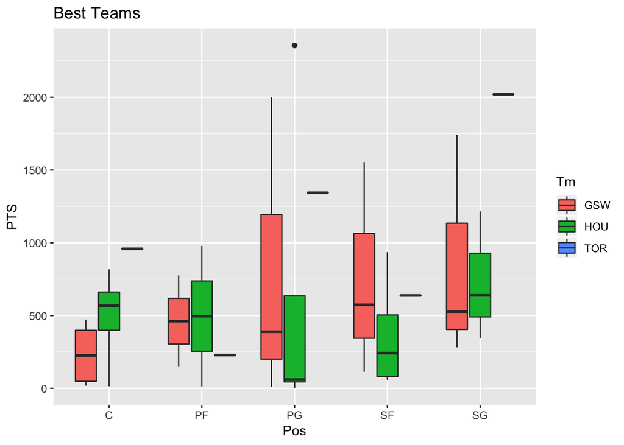

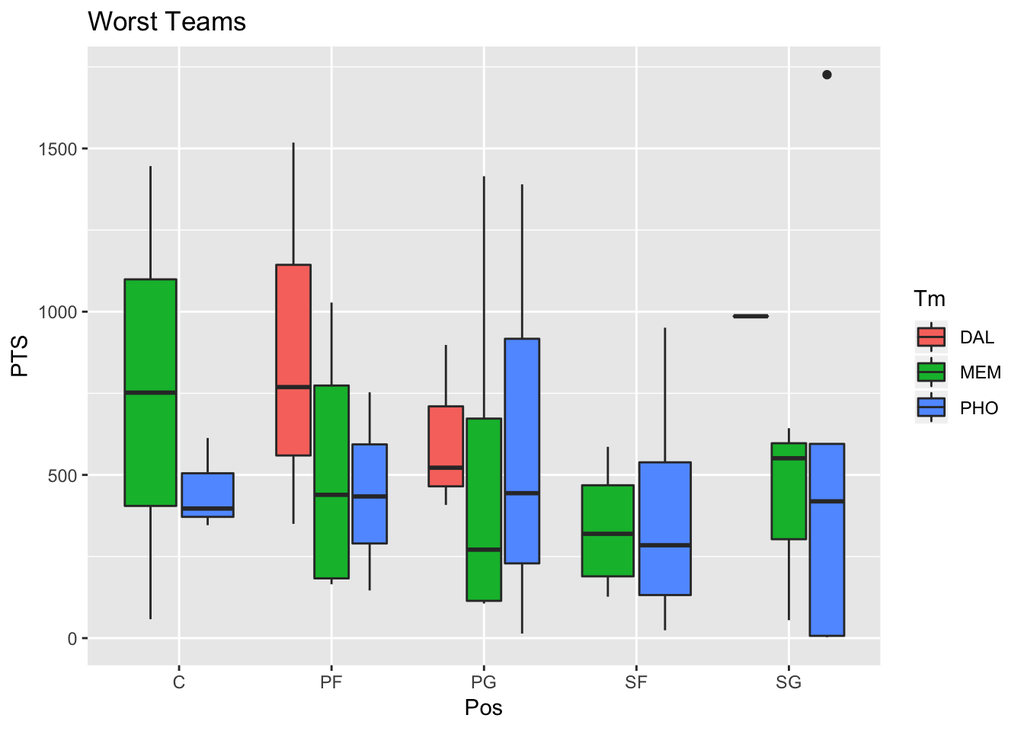

The last thing we wanted to visualize was the distribution of points by age, to see if teams should sign young or old players. We just made a simple boxplot to show the distribution of points scored. We used points scored as our criteria to judge how productive a player is because that had the highest correlation with wins, and it was significant in our model. This graph is shown below.

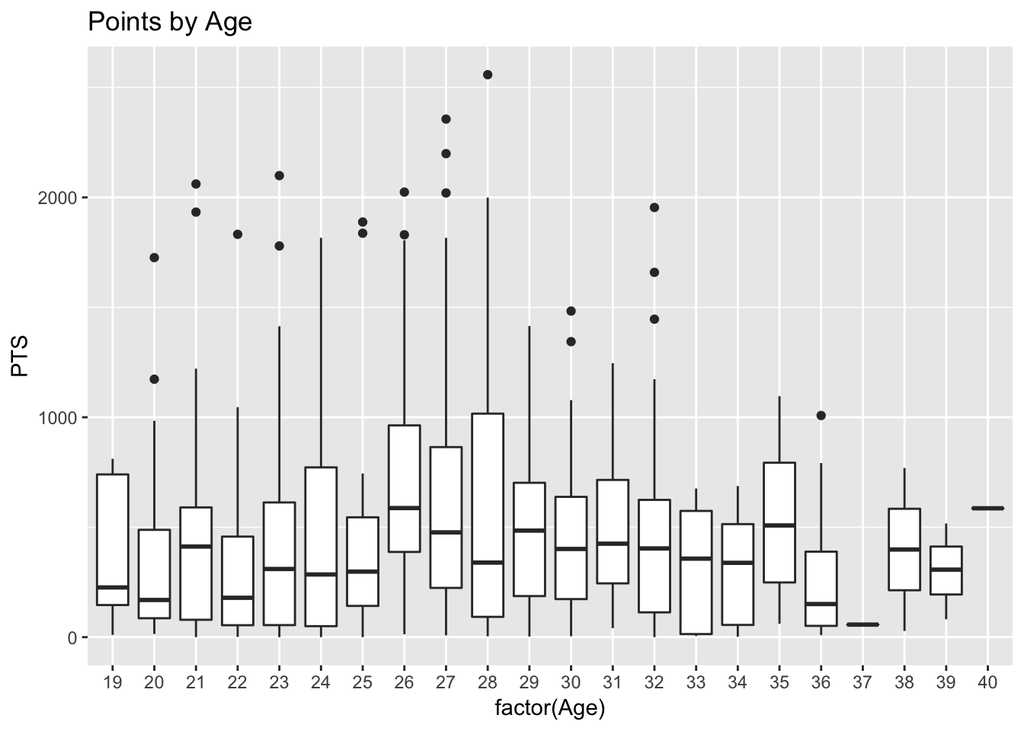

### Answers to Questions Raised

Our first question we were looking to answer was what makes a winning team? We wanted to find out what statistics a player had would contribute to wins the most. To answer our original question, the statistics that make a winning team are the total team points scored in a season and their effective field goal percentage. This means teams must be scoring at a high and efficient rate in order to win games and they do not have to be the most flashy to be efficient. It does not matter how well a team passes, blocks, steals etc., as long as they find out how to score. These results come from our model, as eFG (effective field goal %) and team points were the only variables selected to be significant. However, the adjusted r squared of our model is relatively low with .38. This makes sense because our model only has two predictors, and could potentially underfit the data.

### Conclusion

#### Grant Ruedy’s Contribution

For this project, I helped find the data set that we would be working with from Kaggle. Then I joined that data set with our own taken from basketball reference. I did a lot of the cleaning in terms of subsetting the data and adding team statistics. I also did the modeling in trying to select which variables were important for determining wins, and a lot of the visualization for points by age and position. For the presentation, I made the slides regarding the cleaning, joining, modeling, and some other miscelaneuous slides. We then compiled them and each shared the load of presenting. For the report, I did the fist several questions, Andrew did the last 2.

#### Andrew Sundberg’s Contribution

I made the visuals and slides regarding the second and third questions we were trying to answer. These were the questions regarding which position was the most important and if younger or older players are better. I used Grant’s data sets for the best and worst teams in the visuals for the position and age boxplots. We compiled our slides together to make sure we weren’t redundant. We then ran through the presentation four times the night before our presentation to get a good feel for the content and how long the presentation would take.

##### Sources

“2017-18 NBA Season Summary.” Basketball,  
www.basketball-reference.com/leagues/NBA_2018.html.

Goldstein, Omri. “NBA Players Stats since 1950.” Kaggle, 27 Apr. 2018, www.kaggle.com/drgilermo/nba-players-stats#Seasons_Stats.csv.